# Gater

Andrew Wight

# Abstract

It has been possible for several years now to store, analyze, graph, and summarize flow cytometry data using free and open source software thanks to the R statistical programming language and cytometry-based packages hosted in BioConductor. Unfortunately, despite the obvious benefits of a free and open source cytometry platform with a large existing support base and simple integration with thousands of cutting edge packages and analytical advancements, few cytometerists have adopted R as a complete flow cytometry analysis solution. We believe that this is because drawing gates, a central task in flow cytometry analysis, is still extremely cumbersome in R. Currently, gates must either be automatically derived by unfamiliar computer models or specified by manually typing point-by-point x-y coordintates for each gate. In this vignette, we describe gater, a new package that provides a simple and familiar graphical interface to R that allows gating by drawing gates on top of flow plots. We believe this is the missing piece that will allow even a relative newcomer to R to quickly and confidently perform traditional cytometry analyses. This vignette works through a simple flow analysis workflow in detail, beginning with package setup and data import, compensation, and transformation before displaying how to gate the data using gater, and then concludes with a simple example of how to produce professional-looking graphs and summary statistics from these gates. Some very basic experience with R is assumed, but this vignette is targeted toward a relative beginner and does not assume familiarity with other BioConductor packages or any previous attempts to analyze flow cytometry data in R.

# Introduction

The ability to analyze and manipulate flow cytometry data (in the form of .FCS files) from within the R statistical programming language is becoming increasingly relevant. With improved throughput of flow cytometers through readily available auto-sampling machines and increased complexity enabled by multi-parameter and spectral analyzers, there is a growing need for programmatic and open-source solutions that enable efficient and reproducible cytometry analysis. Moreover, recent advances in flow cytometry, such as the ability to integrate machine learning and conventional cytometry to allow a 16-colour cytometer to analyze hundreds of markers in a single sample (Infinity Flow by Becht et al., https://www.biorxiv.org/content/10.1101/2020.06.17.152926v1), require familiarity with analyzing cytometry data in R. Finally, analyzing cytometry data in a coding language enables more transparent and repeatable science, since it is possible to directly comment on each step of the analysis strategy and to employ version control software to track any changes to the analysis over time.

There are currently two general strategies for working with cytometry data in R. The first is to perform the entire analysis from within the R coding environment. There are some excellent packages and standards that allow the import of FCS files, compensation, data transformation, plotting, and exporting summary statistics. However, manual gating of flow cytometry data remains cumbersome and difficult to perform accurately. Of note, there are packages available now that enable automatic, data-driven gates that avoid these problems, but are themselves complex to properly prepare and validate the automatic gates. Moreover, these data-driven gates represent an unfamiliar workflow for the majority of cytometerists that are accustomed to GUI-based analyses such as those enabled by FlowJo, Kaluza, and other cytometry analysis software.

The second strategy is to first perform compensation, transformation, and gating in FlowJo, and then import the resulting workspace object into R using the flowWorkspace package. This has the advantage of allowing cytometerists to work in a familiar way while still enabling the use of cutting-edge cytometry tools such as Infinity Flow. However, this approach lacks all of the other benefits that an R-native cytometry package would allow. In particular, it is dependent on expensive, closed-source software and does not allow for easy commenting and version control. Nevertheless, manual gating remains sufficiently difficult in R as to make this the method used in the Infinity Flow manuscript.

Gater was developed to fill in this missing ability for manual, GUI-based gating in R, finally enabling a familiar cytometry analysis pipeline completely within R. This vignette will demonstrate the gater function within the context of a complete cytometry analysis pipeline and is geared toward a researcher who has never used R for flow cytometry analysis at all.

# Setting up gater

Prior to using gater, it must first be installed on your system. Because it is in active development and not yet submitted to BioConductor, you will need to install it directly from GitHub. Installing packages from GitHub is slightly more complex than installing normal R packages, so if you’ve never done it before, here are some steps to follow:

1. Install RStudio (https://rstudio.com). Gater uses the Shiny package to make interactive gating possible, which tends to work best from inside the RStudio IDE. You don’t strictly need to use RStudio to make this work, but this vignette is assuming that you are, and if you don’t have a reason not to use RStudio, I recommend that you do at least while you are working through this vignette.
2. If you are using a Windows operating system, install Rtools (https://cran.r-project.org/bin/windows/Rtools/)
3. Make sure that you have a GitHub account (http://github.com)
4. Install BioConductor dependencies (see code below). Once gater is submitted to BioConductor, this step won’t be necessary, but for the mean time, the code we will use to install gater from github doesn’t know how to automatically install dependencies that are hosted on BioConductor, so we need to do it ourselves first. Run the following code on your computer before proceeding:

```r
if(!requireNamespace("BiocManager", quietly = TRUE)){
  install.packages("BiocManager")
}

if(!requireNamespace("flowCore", quietly = TRUE)){
  BiocManager::install("flowCore")
}

if(!requireNamespace("flowWorkspace", quietly = TRUE)){
  BiocManager::install("flowWorkspace")
}

if(!requireNamespace("ggcyto", quietly = TRUE)){
  BiocManager::install("ggcyto")
}
```

Once you have the BioConductor dependencies installed, you should be able to run the following code to download and install gater.

```r
# install devtools if you don't already have it
if(!requireNamespace("devtools", quietly = TRUE)){
  install.packages("devtools")
}

devtools::install_github("NKInstinct/gater")
```

# Preparing your cytometry data

Before you can start drawing gates on your data, you need to read it into R and perform a few transformations on it (compensation and fluorescent channel transforms). If this seems a little complex, don’t worry—it can be a bit much to wrap your head around the first time you do it, but once you know the options you would like to use, you can write them all into a single function and then use that for automatic data import and transformation in the future. We’ll cover preparing just such a function at the end of this section in case you aren’t sure how to do that.

## Assemble a flowSet from seperate .FCS files

The example flow data used in this package comes from the GvHD data included in flowCore, the base package for all flow cytometry data analysis in R. The GvHD data that comes with flowCore is already stored in a flowSet, so for this example, you can find the first three samples from GvHD bundled with gater as individual .FCS files, which we will turn into a flowSet here.

```r
library(gater)
library(flowCore)

path_to_fcs <- system.file("extdata", package = "gater")
```

The `system.file()` command above is needed to get at the .FCS files that have shipped with gater. However, when you are ready to read your own flow data into R, you can provide a simple path to the directory you are interested in. For example, if your target directory is something called “Flow Data” in your current working directory, you could simply pass `path_to_fcs <- “~/Flow Data/” and that would do the same thing.

```r
fs <- read.flowSet(path = path_to_fcs,
                   pattern = ".FCS$",
                   full.names = TRUE)
```

Running this command first finds all of the files at the location specified by path_to_fcs and checks if any of them ends in .FCS (that’s the “pattern =”.FCS$") part of the code). All of them that satisfy the pattern are loaded into a flowSet called fs. Note that there are a lot of customization options here - have a look at the flowCore vignettes if you want to change something about this default behaviour.

### Working with large flowSets

If you have a lot of flow data, you might not want to load it all into a flowSet following the above instructions. This is because the whole flowSet we just created exists in RAM, and if it is extremely large, it might cause problems depending on how much RAM you have available to you. Instead, you can use the ncdfFlow package to directly access the data on your hard drive. This will cause all operations on the data to be slightly slower, but will not consume an enormous chunk of system RAM. It also has some benefits for keeping all your data and analyses together, which we’ll touch on when we talk about saving gated cytometry data. For those reasons, I tend to prefer this NCDF approach for cytometry analysis, but it doesn’t really matter which one you use, especially when just starting out (you can always change your mind later).

```r
# Not run for the purposes of the vignette
library(ncdfFlow)
fs <- read.ncdfFlowSet(files = list.files(path = path_to_fcs,
                                          pattern = ".FCS$",
                                          full.names = TRUE))
```

## Convert the flowSet to a GatingSet

FlowSets are excellent containers for holding flow data, but they cannot store information about gating very well. The flowWorkspace package introduces a new, similar data structure called a GatingSet that holds both the flowSet we just made and all gating information about it. Thankfully, once we have made a flowSet, it is very easy to prepare a GatingSet.

```r
library(flowWorkspace)
gs <- GatingSet(fs)
```

## Compensate the data

So far we have created a flowSet and then turned it into a GatingSet. This GatingSet is a container that can hold many different kinds of information. Currently, it has the raw expression values recorded off of the cytometer and experimental metadata. Both of these were contained in the FCS file, and so were loaded into the flowSet and then brought over to the GatingSet. Next, we are going to add a compensation matrix to this container, so that the data are properly compensated. For these specific example data, the compensation matrix is stored in an external file which we will import and apply to the GatingSet. There are other ways to compensate, which we will mention below.

```r
path_to_comp <- system.file("extdata", "compdata", "compmatrix", package = "flowCore")
comp_matrix <- read.table(path_to_comp, header = TRUE, skip = 2, check.names = FALSE)

comp <- compensation(comp_matrix)

gs <- compensate(gs, comp)
```

### Using acquisition-defined compensation

Although the above example uses an externally-stored compensation matrix, a common use-case will be that you have acquired flow data for which you performed instrument-level compensation. In this case, the compensation matrix is saved directly in the .FCS file upon export, and you can read that into the comp object instead of loading an external file.

There are several places in a .FCS file where a compensation matrix can be stored. My Fortessa X20 stores it in the $SPIL slot of a .FCS, but other cytometers likely behave differently. To find out where yours is, you need to first call `spillover()` on one of the samples in your flowSet (**not the GatingSet!**), and then look at the output. One of the slots that gets returned to you will look like a compensation matrix—take note of which one that is and then store it in a variable called comp.

Here is an example. Note that since the .FCS files used in this example do not have an acquisition-defined compensation, trying to run this code using these data will fail.

```r
# Not run for the purposes of the vignette

# Find out which slot the compensation data are in.
spillover(some_new_fs[[3]])

# You need to select one of the samples contained in the flowSet. I chose the
# third one here ([[3]]), but that is completely arbitrary. The should all have
# the exact same compensation matrix.

# This command should output a list of several objects. One of them should look
# like a compensation matrix. If we were running this command on data from my
# Fortessa, it would be the first object in the list (the $SPIL slot), but look
# at your data and see which object you want to work with. Once you know which
# object is your compensation matrix, proceed.

comp_matrix <- spillover(some_new_fs[[3]])[[1]]

# Note that I have selected the first object in the list, which corresponds to
# where my acquisition-defined matrices are stored. If yours is in a different
# list object, put that object's number in place of the [[1]] above.

# From here, it is exactly like before:

comp <- compensation(comp_matrix)

some_new_gs <- compensate(some_new_gs, comp)
```

### Creating a new compensation matrix from single-colour controls

It is also possible, using the flowCore package, to automatically create a compensation matrix from single colour control samples. Exactly how to do this is beyond the scope of this vignette, so you are encouraged to look into the flowCore vignettes for further instructions. In general, however, it is a bit of a pain to do, so if you know you are going to be using gater for your flow analysis, you are probably better off making sure you have an acquisition-defined compensation matrix or an external compensation matrix saved as a .csv before proceeding.

## Transforming the fluorescent data

The final step before analyzing the flow data is to apply a transformation to the fluorescent channels in the data. There are many different types of transformation available through flowCore, flowWorkspace, and others, but for this vignette we will stick with the biexponential transformation as implemented in FlowJo. To transform the data, we first create a transformation object, and then apply it to the GatingSet, much like we did with compensation. To do this, however, we need to know how many linear channels there are, so that we don’t accidentally apply a biex transform to them as well.

```r
colnames(gs)
```

```
#> [1] "FSC-H" "SSC-H" "FL1-H" "FL2-H" "FL3-H" "FL2-A" "FL4-H" "Time"
```

In this example dataset, there are three linear channels we don’t want to transform: “FSC-H”, “SSC-H”, and “Time”. With a small number of parameters like this, we can simply name them manually, like so:

```r
channels <- c("FL1-H", "FL2-H", "FL3-H", "FL2-A", "FL4-H")
channels
```

```
#> [1] "FL1-H" "FL2-H" "FL3-H" "FL2-A" "FL4-H"
```

However, if there were a lot of channels, or if we wanted to write a general function to handle any flow data in the future, it would be better to define this programmatically:

```r
channels <- colnames(gs)[!stringr::str_detect(colnames(gs), "^FSC-.$|^SSC-.$|^Time$")]
channels
```

```
#> [1] "FL1-H" "FL2-H" "FL3-H" "FL2-A" "FL4-H"
```

If you haven’t worked much with strings and regular expressions yet, check out the stringr package for more information on how that code works. Essentially, it is storing all of the colnames in our GatingSet object that do not follow the pattern of being “FSC-” or “SSC-” followed by a letter (so all of the different variants of forward and side scatter) or variables that are exactly named “Time” (rather than variables that contain the word “Time”, which could potentially accidentally exclude some exotic protein names).

Now that we have a list of all of our non-linear channels, we can transform them.

```r
transformation_object <- flowjo_biexp_trans()

transformation_list <- transformerList(channels, transformation_object)

gs <- transform(gs, transformation_list)
```

## Putting it all together—create an import function

As mentioned above, all of that seems like a lot of work just to import the flow data into R. However, a lot of the complexity of this import step comes from not knowing exactly how your specific experiment is set up. Once you know that, you can write all of this into a single function that holds all of your defaults, and then you can just call that function to import your data. If we were to do that with the above data import, it would look something like this:

```r
import_gs <- function(path, pattern, compensation_matrix){
  fs <- read.flowSet(path = path, pattern = pattern, full.names = TRUE)
  gs <- GatingSet(fs)

  comp <- compensation(compensation_matrix)
  gs <- compensate(gs, comp)

  channels <- colnames(gs)[!stringr::str_detect(colnames(gs), "^FSC-.$|^SSC-.$|^Time$")]
  transformation_object <- flowjo_biexp_trans()
  transformation_list <- transformerList(channels, transformation_object)
  gs <- transform(gs, transformation_list)

  return(gs)
}
```

Now that we have defined this function, we can do all of the above steps in a couple of lines of code:

```r
path_to_fcs <- system.file("extdata", package = "gater")
path_to_comp<- system.file("extdata", "compdata", "compmatrix", package = "flowCore")
comp_matrix <- read.table(path_to_comp, header = TRUE, skip = 2, check.names = FALSE)

gs <- import_gs(path = path_to_fcs,
                pattern = ".FCS$",
                compensation_matrix = comp_matrix)
```

This is a pretty basic function, and there’s a lot more we could do to make it more useful for other experiments with slightly different conditions, but it’s a good start for now and hopefully demonstrates that once you have the hang of it, importing cytometry data into R is neither difficult nor time consuming.

# Interactive gating

Now that we have a compensated and transformed GatingSet object holding all of our flow cytometry data, it is time to start gating through it. If you were working on your own data, you would probably be able to jump right in knowing what parameters are in your dataset, but since this is an example set, it is helpful to have a quick look at the channel names contained in the data.

There are two kinds of names for each channel in this GatingSet object: the detector name (such as “FL1-H”) and, if specified, the marker name (such as “CD15 FITC”). We can access the first kind of name with `colnames()` like we did above, and the second kind with `markernames()`:

```r
colnames(gs)
```

```
#> [1] "FSC-H" "SSC-H" "FL1-H" "FL2-H" "FL3-H" "FL2-A" "FL4-H" "Time"
```

```r
markernames(gs)
```

```
#>        FL1-H        FL2-H        FL3-H        FL4-H
#>  "CD15 FITC"    "CD45 PE" "CD14 PerCP"   "CD33 APC"
```

Note that not every detector name has a corresponding marker name. Thankfully, gater can handle either kind of name interchangeably, so it’s not hard to use whichever is more appropriate for the situation.

## Draw your first gate

As with most cytometry experiments, the first thing we are going to look at is cells, as defined by their forward and side scatter. Ironically, because this vignette is non-interactive, you will have to do some of the legwork here yourself to draw your gates. I will annotate this to help you follow along, but your best bet is to run this code while reading to see how it works.

```r
gs_gate_interactive(gs,
                    filterId = "Leukocytes",
                    dims = list("FSC-H", "SSC-H"))
```

```
#> [1] 2
```

When you first run the gs_gate_interactive command, a window like this should appear

[figure not shown]

The sidebar on the left lets you decide what kind of gate you want to draw, and the main window in the middle shows a plot of your data that you can interact with.

To draw a gate, the first thing you need to do is pick what kind of gate you want to draw. It is very important that you pick the kind of gate you want to draw **first**, and then draw it second. Doing it the other way tends to cause errors.

To select your leukocytes, switch the gating mode over to polygon by clicking on the polygon radio button

[figure not shown]

Once you have clicked on the kind of gate you want, you can proceed to draw it. Polygon gates (like this one) are drawn by clicking multiple times to trace a polygon. Other gates are drawn differently (Rectangle and Span gates are drawn by clicking and dragging a rectangle, and Quadrant gates are drawn by clicking once where the four quadrants meet). Note that when you draw a Polygon gate, the image doesn’t update to show your polygon in realtime - you’ll just have to remember where you put your points (though we’re working on a better implementation of this now).

Go ahead and draw a polygon gate on your data. Again, remember that you won’t see your polygon while you draw it.

[figure not shown]

If you think you’ve mis-clicked and want to start over, just hit the “Clear” button on the top left and then start drawing your polygon again. Once you are happy with it, click “Done” to close the window and apply the gate to your whole GatingSet.

### Other notes about gating

If something goes wrong when you are drawing your gates (such as if you draw a polygon gate when you still have “rectangle gate” selected), the shiny app can hang. If you exit out of the shiny window without clicking on “done” first, it’s a good idea to make sure that the shiny app isn’t still running in the background. Have a look at your R Console window and see if there is a stop sign in the upper-right corner.

[figure not shown]

If that button is there, it means that the shiny app is still running and you should stop it before proceeding. Trying to do anything else in R while the shiny app runs in the background can cause all kinds of mysterious errors.

Another thing to note is that when we run `gs_gate_interactive()` on our data, the resulting gate gets stored in the GatingSet along with everything else. Sometimes, it can be helpful to have that gate stored in its own variable within R, such as when you want to apply the same gate to multiple nodes within the GatingSet, you want to apply it to different GatingSets, or you just want an easily referenced record of the gate’s dimensions. To do this, simply assign the output of `gs_gate_interactive()` to a variable name, such as `gate1 <- gs_gate_interactive()`. Note that all of these actions can also be performed on gates within a GatingSet using the flowWorkspace package, but if you know ahead of time that you are going to want the gate for multiple purposes, it is easier to assign it to a variable and then go from there.

## Plot the data with the new gate

Now that we have drawn a leukocytes gate, it is a good idea to have a look at the plot and see that it looks the way we want it to. There are a number of ways to plot flow cytometry data in R—my favourite is with the ggcyto package, which is automatically installed with gater for visualization purposes. Since we only want to peek at the data right now to make sure our gate looks right, we can use the easy-but-rigid `autoplot()` function, like so:

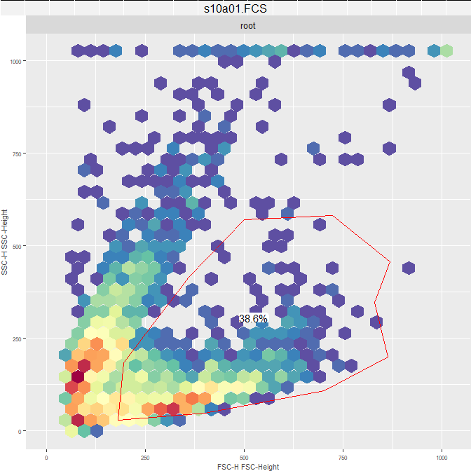

```r
autoplot(gs[[1]], gate = "Leukocytes")
```

The important thing here is that you have a gate drawn on a hex plot with a percentage in the middle of it—don’t worry if it doesn’t look exactly like the one here, and don’t worry if the plot doesn’t look the way you want it to for publication. We’ll cover how to make very nice plots at the end.

**Common Mistake:** if, when you run autoplot, you don’t see a gate but you do see a big “0%” sitting roughly where your gate should be, that means you didn’t switch the window to polygon gate before drawing your polygon, and the program is trying to make a rectangle gate out of the very first point you clicked for your polygon (hence an invisibly-small rectangle with 0% of the events in it). Again, we’re working on making this mistake harder to make, but for now, just redo the gate by re-running `gs_gate_interactive()` again. Just make sure you add `regate = TRUE` to the command so gater knows to delete this Leukocytes gate before trying to add another Leukocytes gate to root.

## Draw more gates

Now that we have a Leukocytes gate drawn, we can drill down into them and gate on the other markers in our sample. The next likely gate will be to take all of the CD45+ cells for further analysis. For illustrative purposes, let’s gate this one with a 1-D span gate on a histogram.

```r
gs_gate_interactive(gs,
                    filterId = "CD45",
                    dims = "CD45",
                    subset = "Leukocytes")
```

```
#> [1] 3
```

[figure not shown]

Switch the gating mode over to “Span”

[figure not shown]

Then draw your gate. For span and rectangle gates, you draw them by clicking and dragging a rectangle on the plot. In fact, the only difference between span and rectangle gates is that span only considers the horizontal dimensions, while rectangle considers both. So for this gate, you can draw the rectangle as *tall* as you want, since span gates don’t care about the vertical dimensions of the rectangle. This can be useful for drawing the gate exactly where you want it, since you can use the vertical dimensions to help line it up with your histogram peaks.

[figure not shown]

As before, when you are happy with the gate, click Done to close the window and apply the gate. Unlike with polygon and quadrant gates, you don’t need to click Clear if you want to adjust the rectangle on your graph—you can just adjust or redraw it as many times as you like (note: nothing bad will happen if you click Clear when drawing rectangles, so don’t worry if you do).

Now, as before, we can have a peek at the gate. This time, however, we’re going to use the more expanded ggcyto command to start to get familiar with it. ggcyto uses the same grammar of graphics that ggplot uses, so if you are already familiar with ggplot, this should be very straightforward. If not, a full introduction to the grammar of graphics is beyond the scope of thie vignette, but look at the code below and see if you can follow what is happening.

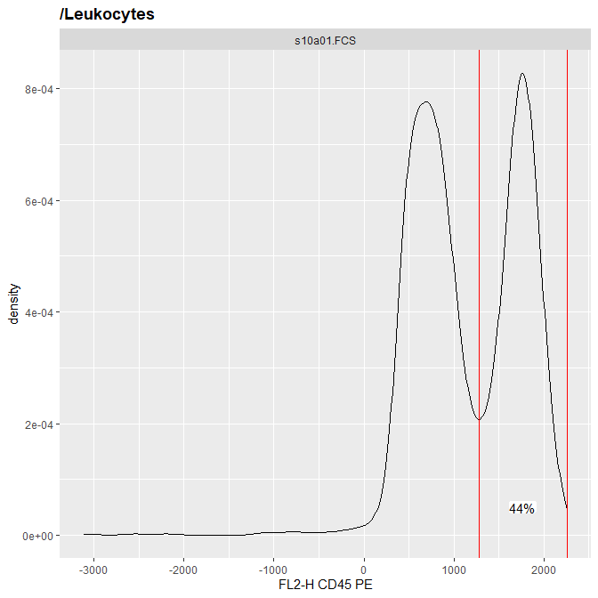

```r
ggcyto(gs[[1]], aes("CD45")) +
  geom_density() +
  geom_gate("CD45") +
  geom_stats()
```

The idea behind the grammar of graphics is that you can draw any graph by first specifying the data the graph comes from, and then specifying the kind of image you want to make from those data. In this case, the first line of code tells ggcyto that we want to make a graph based on the first sample contained in gs (`gs[[1]]`), and that we want to look at the CD45 dimension of these data. In the grammar of graphics, this is called an aesthetic, hence “aes”.

After this line specifying what sort of data we want to look at, the next three apply types of images to the data. The first, `geom_density()`, draws a density plot of the CD45 aesthetic in our data. The second, `geom_gate("CD45")`, adds the gate named “CD45” to our data. The third, `geom_stats()`, adds all relevant stats (in this case the percent parent) to any gates drawn on the graph.

Using `ggcyto()` instead of `autoplot()` is a little more cumbersome to type, but provides much more customization to the resulting graph, and is well worth learning how to use if you are regularly going to use R and gater for flow analysis. For that reason, the rest of this vignette will use `ggcyto()` calls to generate graphs, so we can get more familiar with what they look like.

## Draw the last quadrant gate

The last gate to add to this plot is a quadrant gate on CD33 and CD15. As before, we’ll call `gs_gate_interactive()` with the appropriate arguments, then switch our gating mode to quadrant, and then click exactly once, where you want the center of the quadrant gate to be. As with the polygon gate, if you mis-click, you can click on Clear to reset your selection and then try again.

```r
gs_gate_interactive(gs[[1]],
                    filterId = "CD33 CD15",
                    dims = list("CD33", "CD15"),
                    subset = "CD45",
                    bins = 64)
# I set the bins lower because we have fewer cells after drilling down twice
```

```
#> [1] 4 5 6 7
```

As before, we can check the gate by plotting it with ggcyto

```r
ggcyto(gs[[1]], aes("CD33", "CD15")) +
  geom_hex(bins = 64) +
  geom_gate("CD33 CD15") +
  geom_stats()
```

[output not shown]

You may already have a hunch of what’s going on here, but to check for sure, it’s a good idea to ask gs for the names of all stored gates

```r
gs_get_pop_paths(gs)
```

```
#> [1] "root"                                 "/Leukocytes"
#> [3] "/Leukocytes/CD45"                     "/Leukocytes/CD45/CD33 APC-CD15 FITC+"
#> [5] "/Leukocytes/CD45/CD33 APC+CD15 FITC+" "/Leukocytes/CD45/CD33 APC+CD15 FITC-"
#> [7] "/Leukocytes/CD45/CD33 APC-CD15 FITC-"
```

As you can see above, when you draw a quadrant gate, it actually puts four new gates on the plot (one for each quadrant). Since all four of these can’t be named “CD33 CD15”, the quadrant gate ignores the filterId you give it and makes up unique names for the four gates based on the marker names involved in the plot. So to plot this quadrant gate, we need to specify all four of these gates.

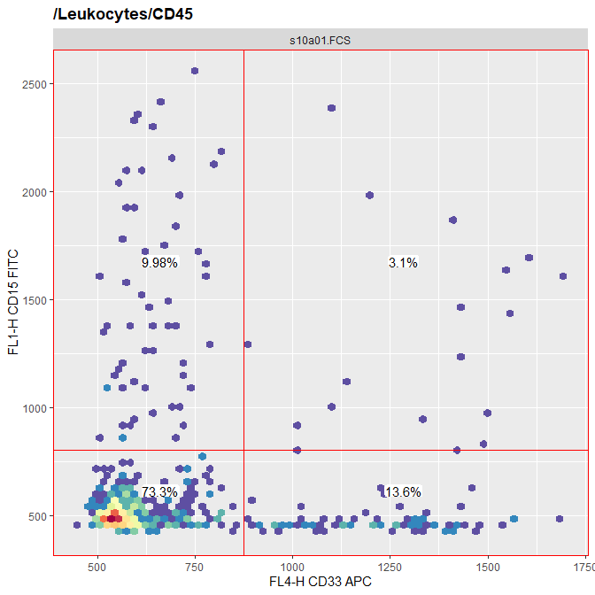

```r
ggcyto(gs[[1]], aes("CD33", "CD15")) +
  geom_hex(bins = 64) +
  geom_gate(c("CD33 APC-CD15 FITC+",
              "CD33 APC+CD15 FITC+",
              "CD33 APC+CD15 FITC-",
              "CD33 APC-CD15 FITC-")) +
  geom_stats()
```

If you are comfortable with the stringr package, you can also specify this a little more efficiently by first selecting all of the population paths that contain the word “CD33” and then passing this list to geom\_gate:

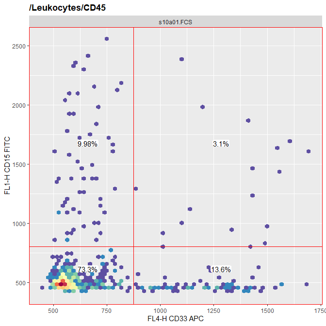

```r
quadgates <- gs_get_pop_paths(gs)[stringr::str_detect(gs_get_pop_paths(gs), "CD33")]

ggcyto(gs[[1]], aes("CD33", "CD15")) +
  geom_hex(bins = 64) +
  geom_gate(quadgates) +
  geom_stats()
```

Again, this isn’t that important, so if stringr is unfamiliar to you, don’t worry about it yet and come back to this idea when you’re more comfortable with working with strings.

## Save your GatingSet object

Once you have your gates drawn to your satisfaction, the last thing to do is to save your GatingSet object so that you don’t need to re-draw your gates when you come back to them. One detail about the flowWorkspace package that we haven’t covered yet is that GatingSet objects are very different from most R objects, and so saving your GatingSet using normal R proceedures will fail (i.e. if you try to save it as a .Rds it won’t load properly). If you want to understand what is going on under the hood, have a look at the flowWorkspace vignette. To save this object, you need the `save_gs()` function from flowWorkspace. This saves your GatingSet object as a directory that you can then load in with `load_gs()`. Although not necessary, I like to end this directory name with “.gs” to remind myself that the whole directory is the GatingSet object, so it’s helpful to think of it more like a single file than a directory.

```r
save_gs(gs, "GvHD GatingSet.gs")

#Load it back in
gs <- load_gs(file.path("GvHD GatingSet.gs"))
```

One very important note here—the `load_gs()` command is very sensitive to the way file paths are specified in a system, and in particular fails when you try to use it in a Windows environment. Wrapping your filepath with `file.path()` from base R will solve this problem and make it work across any OS.

It’s also worth mentioning that another benefit of the NCDF style of flow cytometry data that we mentioned all the way back in data import is that the NCDF data itself gets saved inside this GatingSet, which means that the whole thing (data, gates, compensation, etc) are stored in your GatingSet.gs directory. This is another reason that I like using the NCDF style of import, but as long as you don’t move the .FCS files that are making up your GatingSet, you shouldn’t run into any problems if you load the GatingSet through the conventional workflow (just like in FlowJo - don’t move your FCS files around after starting to analyze them!).

# Data Export—Images and Summary Statistics

Now that we have gated on our samples, the last step is to have a look at the different flow samples and pick some example plots to show others, as well as extract statistics like percent of parent populations and MFI. Again, the flowCore, ggcyto, and flowWorkspace packages are very feature-rich in this department, so what we will show below is only the tip of the iceberg. However, this should cover many of the conventional cytometry use cases and let you do complete, basic cytometry analysis using only R.

## Plot data nicely

In our above analysis, let’s pretend that the final goal was to show whether CD33 and CD15 expression changes between the different samples. Since there’s only three samples in the GatingSet, the best way to do this is just plot three dotplots showing each sample’s CD33 and CD15 expression, gated with our quadrant gate. Fortunately, we already know how to do this. Remember how above, each time we plotted something, we specified that we only wanted the first sample in gs with `gs[[1]]`? All we need to do is not specify anything and ggcyto will plot all three graphs.

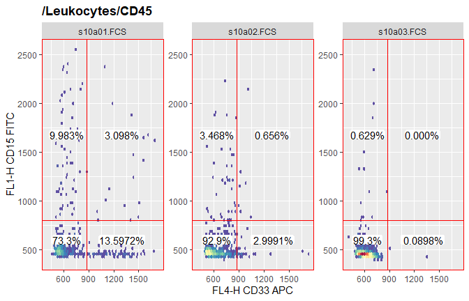

```r
quadgates <- gs_get_pop_paths(gs)[stringr::str_detect(gs_get_pop_paths(gs), "CD33")]

ggcyto(gs, aes("CD33", "CD15")) +
  geom_hex(bins = 64) +
  geom_gate(quadgates) +
  geom_stats()
```

These graphs do a good job conveying the information we want to show, but they look a little primitive compared to graphs that FlowJo produces, so let’s try to use the huge customization possibilities in ggcyto to make them a little nicer. We’ll change three things: change the gates from bright red to a semi-transparent grey, make the stats overlays slightly more friendly numbers, and increase the bins to make the dots a little less crude. Have a look at the code below and see if you can understand what is happening before reading on.

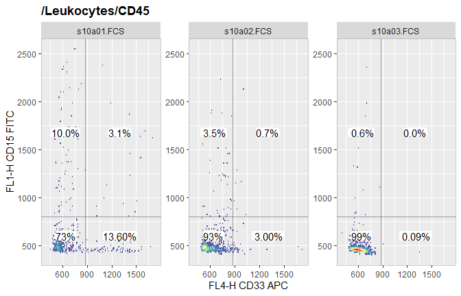

```r
ggcyto(gs, aes("CD33", "CD15")) +
  geom_hex(bins = 128) +
  geom_gate(quadgates, colour = "grey3", alpha = 0.2) +
  geom_stats(digits = 1)
```

That’s starting to look much classier, while still clearly presenting the data. The last thing I like to do with presentation plots is to remove the grey in the background. Changing the overall appearance of a plot is accomplished with the `theme_` family of layers to add to a ggcyto object. There are some default themes, as well as packages with other nice ones out there. It’s also possible to get extremely fine control over theme elements with the `theme()` layer, but that’s an advanced topic that you should look into the first time you run into a theme problem you can’t fix with a pre-loaded one.

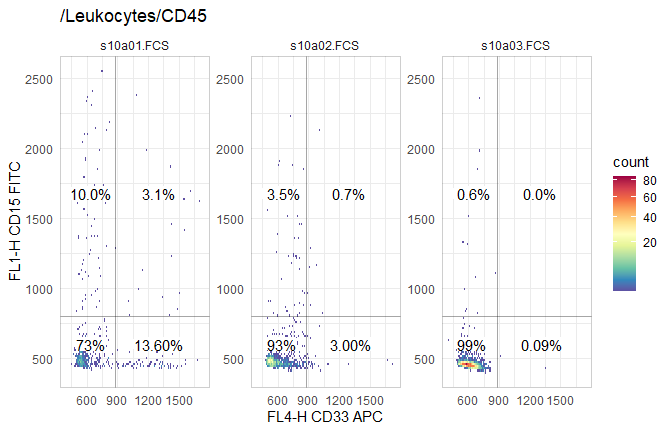

```r
ggcyto(gs, aes("CD33", "CD15")) +
  geom_hex(bins = 128) +
  geom_gate(quadgates, colour = "grey3", alpha = 0.2) +
  geom_stats(digits = 1) +
  theme_minimal()
```

## Retrieving summary statistics

In this case, we only care about CD33 and CD15 expression on three samples, so the graphs above are sufficient to convey all the information we want. Normally, however, it’s necessary to retrieve some summary statistics such as percent of parent or MFI from many different populations and then graph them somehow. flowWorkspace has a number of functions we can use to access this information. The easiest is `gs_pop_get_counts_fast()`, which returns a basic table of population counts without any fuss.

```r
gs_pop_get_count_fast(gs)
```

```
#>           name                           Population           Parent Count
#>  1: s10a01.FCS                          /Leukocytes             root  1320
#>  2: s10a01.FCS                     /Leukocytes/CD45      /Leukocytes   581
#>  3: s10a01.FCS /Leukocytes/CD45/CD33 APC-CD15 FITC+ /Leukocytes/CD45    58
#>  4: s10a01.FCS /Leukocytes/CD45/CD33 APC+CD15 FITC+ /Leukocytes/CD45    18
#>  5: s10a01.FCS /Leukocytes/CD45/CD33 APC+CD15 FITC- /Leukocytes/CD45    79
#>  6: s10a01.FCS /Leukocytes/CD45/CD33 APC-CD15 FITC- /Leukocytes/CD45   426
#>  7: s10a02.FCS                          /Leukocytes             root  1273
#>  8: s10a02.FCS                     /Leukocytes/CD45      /Leukocytes  1067
#>  9: s10a02.FCS /Leukocytes/CD45/CD33 APC-CD15 FITC+ /Leukocytes/CD45    37
#> 10: s10a02.FCS /Leukocytes/CD45/CD33 APC+CD15 FITC+ /Leukocytes/CD45     7
#> 11: s10a02.FCS /Leukocytes/CD45/CD33 APC+CD15 FITC- /Leukocytes/CD45    32
#> 12: s10a02.FCS /Leukocytes/CD45/CD33 APC-CD15 FITC- /Leukocytes/CD45   991
#> 13: s10a03.FCS                          /Leukocytes             root  2319
#> 14: s10a03.FCS                     /Leukocytes/CD45      /Leukocytes  2227
```

[output cut: 23 more lines]

However, geting anything useful out of that table will require a bit more data cleaning. Instead, we can use `gs_pop_get_stats()`, which is a more robust version of `gs_pop_get_counts_fast()`. Here, we can specify whether we want percent (of parent) or count, or can even specify our own functions to derive a stat. We can also specify certain gates if we don’t want to look at all the populations contained within the GatingSet.

```r
gs_pop_get_stats(gs, type = "percent")
```

```
#>         sample                                  pop      percent
#>  1: s10a01.FCS                                 root 1.0000000000
#>  2: s10a01.FCS                          /Leukocytes 0.3859649123
#>  3: s10a01.FCS                     /Leukocytes/CD45 0.4401515152
#>  4: s10a01.FCS /Leukocytes/CD45/CD33 APC-CD15 FITC+ 0.0998278830
#>  5: s10a01.FCS /Leukocytes/CD45/CD33 APC+CD15 FITC+ 0.0309810671
#>  6: s10a01.FCS /Leukocytes/CD45/CD33 APC+CD15 FITC- 0.1359724613
#>  7: s10a01.FCS /Leukocytes/CD45/CD33 APC-CD15 FITC- 0.7332185886
#>  8: s10a02.FCS                                 root 1.0000000000
#>  9: s10a02.FCS                          /Leukocytes 0.3738619677
#> 10: s10a02.FCS                     /Leukocytes/CD45 0.8381775334
#> 11: s10a02.FCS /Leukocytes/CD45/CD33 APC-CD15 FITC+ 0.0346766635
#> 12: s10a02.FCS /Leukocytes/CD45/CD33 APC+CD15 FITC+ 0.0065604499
#> 13: s10a02.FCS /Leukocytes/CD45/CD33 APC+CD15 FITC- 0.0299906279
#> 14: s10a02.FCS /Leukocytes/CD45/CD33 APC-CD15 FITC- 0.9287722587
#> 15: s10a03.FCS                                 root 1.0000000000
#> 16: s10a03.FCS                          /Leukocytes 0.6751091703
#> 17: s10a03.FCS                     /Leukocytes/CD45 0.9603277275
#> 18: s10a03.FCS /Leukocytes/CD45/CD33 APC-CD15 FITC+ 0.0062864841
#> 19: s10a03.FCS /Leukocytes/CD45/CD33 APC+CD15 FITC+ 0.0000000000
#> 20: s10a03.FCS /Leukocytes/CD45/CD33 APC+CD15 FITC- 0.0008980692
#> 21: s10a03.FCS /Leukocytes/CD45/CD33 APC-CD15 FITC- 0.9928154468
#>         sample                                  pop      percent
```

```r
gs_pop_get_stats(gs, type = "percent", nodes = "CD45")
```

```
#>        sample  pop   percent
#> 1: s10a01.FCS CD45 0.4401515
#> 2: s10a02.FCS CD45 0.8381775
#> 3: s10a03.FCS CD45 0.9603277
```

Specifying our own function is how we get MFI from this command, although the resulting table is a little different in that it returns the MFI for each channel for each population:

```r
gs_pop_get_stats(gs, type = pop.MFI)
```

```
#>         sample                                  pop FSC-Height SSC-Height CD15 FITC
#>  1: s10a01.FCS                                 root      197.0      145.5  517.4555
#>  2: s10a01.FCS                          /Leukocytes      346.0      106.0  480.1491
#>  3: s10a01.FCS                     /Leukocytes/CD45      331.0       87.0  499.3827
#>  4: s10a01.FCS /Leukocytes/CD45/CD33 APC-CD15 FITC+      428.0      232.0 1377.8764
#>  5: s10a01.FCS /Leukocytes/CD45/CD33 APC+CD15 FITC+      390.5      129.0 1259.4863
#>  6: s10a01.FCS /Leukocytes/CD45/CD33 APC+CD15 FITC-      336.0       71.0  456.1987
#>  7: s10a01.FCS /Leukocytes/CD45/CD33 APC-CD15 FITC-      320.0       84.0  497.4192
#>  8: s10a02.FCS                                 root      155.0       73.0  464.5641
#>  9: s10a02.FCS                          /Leukocytes      311.0       88.0  475.5759
#> 10: s10a02.FCS                     /Leukocytes/CD45      322.0       88.0  476.7680
#> 11: s10a02.FCS /Leukocytes/CD45/CD33 APC-CD15 FITC+      477.0      291.0 1218.3777
#> 12: s10a02.FCS /Leukocytes/CD45/CD33 APC+CD15 FITC+      639.0      369.0 1153.6484
#> 13: s10a02.FCS /Leukocytes/CD45/CD33 APC+CD15 FITC-      385.5      113.5  463.6175
#> 14: s10a02.FCS /Leukocytes/CD45/CD33 APC-CD15 FITC-      315.0       85.0  475.9509
```

[output cut: 31 more lines]

## Where to go from here

As with any tabular data in R, you can save any of these results tables as .csv files by storing them in a variable and then calling `write.csv()` around it:

```r
results <- gs_pop_get_stats(gs, type = "percent")

writs.csv(results, "results.csv")
```

This would let you analyze these data in any software you like, just like you already do with your analysis software of choice. However, R is a powerhouse of analysis and graphing capabilities, and so the best thing to do with these data is to analyze and display them in R. This is a huge subject that goes far beyond the scope of this vignette, but if you’ve never tried R’s graphing and data carpentry capabilities before, I highly recommend Wickham and Grolemund’s R for Data Science (https://r4ds.had.co.nz/), which will give you an excellent introduction to all of these subjects and let you quickly plot graphs from these data without needing any external software.